# Retirement Income Toolkit - Economic Scenario - VAR

Queenie Huang

```r
library(tidyverse)
library(ggplot2)
library(gridExtra)
library(readxl)
library(janitor)
library(lubridate)
library(vars)
library(tseries)
library(corrplot)
library(kableExtra)
library(reshape2)
library(latex2exp)
library(aTSA)
library(caret)
library(Metrics)
```

A VAR(p) process can be represented by
$$\begin{align*}
\boldsymbol{Y}_t = \boldsymbol{\alpha }+ A_1 \boldsymbol{Y}_{t-1} + \ldots + A_p \boldsymbol{Y}_{t-p} + \boldsymbol{\epsilon},
\end{align*}$$
where $n$ is the number of economic/financial variables, $p$ is the lag, $\boldsymbol{\epsilon}$ is a white noise process, $A_1, \ldots, A_p$ are fixed coefficient matrices.

# 1 Economic/financial variables

```r
# variables = read_excel("Variables.xlsx")

all_var_names = c("zcp3m", "zcp10y", "home_index", "rental_yield", "GDP", "CPI", "ASX200", "forex") # those to be kept
all_data_original = as.data.frame(matrix(NA, nrow = 112, ncol = 1+length(all_var_names)))
colnames(all_data_original) = c("Date", all_var_names)


# kbl(variables) %>% kable_styling(latex_options = c("striped", "scale_down"))
```

# 2 Assess data quality & cleaning

## 2.1 Data quality

```r
start_pc_date = as.Date("1993-04-01")
start_index_date = as.Date("1993-1-01") # indexes are converted to percentages, one period short
end_date = as.Date("2021-03-31")

################################################
# ZERO-COUPON INTEREST RATES – ANALYTICAL SERIES
# import
zcp = read.csv("zcp.csv")
zcp$date = as.Date(zcp$date)

# match the time window
zcp = zcp %>% filter(date <= end_date & date >= start_pc_date)
zcp = zcp %>% mutate(Qtr = as.yearqtr(date)) %>% group_by(Qtr) %>% summarise_at(vars(-date), mean)

# declare as a ts object
zcp3m = ts(zcp$x1_qtrs / 100)
zcp10y_spread = ts((zcp$x40_qtrs - zcp$x1_qtrs)/100)

all_data_original$zcp3m = zcp$x1_qtrs / 100
all_data_original$zcp10y = zcp$x40_qtrs / 100
all_data_original$Date = zcp$Qtr

###############
# Mortgage rate
# lending = read_excel("Mortgage-RBA.xls", sheet = "Data")[-c(1:10), c(1,4)]
# names(lending) = c("Date", "mortgage_rate")
# lending = lending %>% mutate_if(is.character, as.numeric)
# lending$Date = as.Date(lending$Date, origin = "1899-12-30")
#
# # match the time window
# lending = lending %>% filter(Date <= end_date & Date >= start_pc_date)
#
# # match the frequency
# lending = lending %>% mutate(Qtr = as.yearqtr(Date)) %>% group_by(Qtr) %>% summarise(mortgage_rate_qtr = mean(mortgage_rate))
#
# # declare as a ts object
# lending = ts(lending$mortgage_rate_qtr)

######################################
# House price dynamics & rental yields
# import & cleaning
properties = read.csv("Market_Trends_Data.csv")
properties = clean_names(properties)
properties = properties %>% mutate_if(is.character, as.factor)
properties$value_at_date = as.Date(properties$value_at_date, format =  "%d/%m/%Y")

home_value_houses_nsw = properties %>%
    filter(state == "NSW", property_type == "Houses") %>%
    group_by(value_at_date) %>%
    summarise(index = mean(hedonic_home_value_index, na.rm = T))
rental_houses_nsw = properties %>%
    filter(state == "NSW", property_type == "Houses") %>%
    group_by(value_at_date) %>%
    summarise(yield = mean(hedonic_rental_yields, na.rm = T))
home_value_houses_nsw = home_value_houses_nsw %>%
    filter(value_at_date <= end_date & value_at_date >= start_index_date) %>%
    mutate(Qtr = as.Date(as.yearqtr(value_at_date)))
rental_houses_nsw = rental_houses_nsw %>%
    filter(value_at_date <= end_date & value_at_date >= start_pc_date) %>%
    mutate(Qtr = as.Date(as.yearqtr(value_at_date)))

# match the frequency
home_value_houses_nsw = home_value_houses_nsw %>%
    group_by(Qtr) %>%
    summarise(home_val_qtr = mean(index))
rental_houses_nsw = rental_houses_nsw %>%
    group_by(Qtr) %>%
    summarise(rental_yields_qtr_rate = mean(yield))

all_data_original$home_index = home_value_houses_nsw$home_val_qtr[-1]
all_data_original$rental_yield = rental_houses_nsw$rental_yields_qtr_rate

# match the unit
home_value_houses_nsw = home_value_houses_nsw %>% mutate(home_value_qtr_rate = log(home_val_qtr) - log(dplyr::lag(home_val_qtr, n = 1)))
home_value_houses_nsw = home_value_houses_nsw[-1,]

# declares variables as time_series objects
home_value_houses_nsw = ts(home_value_houses_nsw$home_value_qtr_rate)
rental_houses_nsw = ts(rental_houses_nsw$rental_yields_qtr_rate)

####################################################################
# Gross domestic product: Chain volume measures; seasonally adjusted
# import
gdp = read_excel("GDP-ABS.xls", sheet = "Data1")[-c(1:9), c(1,54)]
names(gdp) = c("Date", "GDP")
gdp = gdp %>% mutate_if(is.character, as.numeric)
gdp$Date = as.Date(gdp$Date, origin = "1899-12-30")

# match the time window
gdp = gdp %>% filter(Date <= end_date & Date >= start_index_date)

# match the frequency
gdp = gdp %>% mutate(Qtr = as.yearqtr(Date)) %>% dplyr::select(-Date)
all_data_original$GDP = gdp$GDP[-1]

# match the unit
gdp = gdp %>% mutate(gdp_rates = log(GDP) - log(dplyr::lag(GDP, n = 1)))
gdp = gdp[-1,]

# declare as a ts object
gdp = ts(gdp$gdp_rates)

#####################################
# CPI: Australia; seasonally adjusted
# import
cpi = read_excel("CPI-ABS.xls", sheet = "Data1")[-c(1:9), c(1,10)]
names(cpi) = c("Date", "CPI")
cpi = cpi %>% mutate_if(is.character, as.numeric)
cpi$Date = as.Date(cpi$Date, origin = "1899-12-30")

# match the time window
cpi = cpi %>% filter(Date <= end_date & Date >= start_index_date)

# match the frequency
cpi = cpi %>% mutate(Qtr = as.yearqtr(Date)) %>% dplyr::select(-Date)
all_data_original$CPI = cpi$CPI[-1]

# match the unit
cpi = cpi %>% mutate(cpi_rate = log(CPI) - log(dplyr::lag(CPI, n = 1)))
cpi = cpi[-1,]

# declare as a ts object
cpi = ts(cpi$cpi_rate)


#################################
# S&P/ASX200: daily closing price
# import
asx200 = read.csv("asx200_price.csv")
asx200$exchange_date = as.Date(asx200$exchange_date)

# match the time window
asx200 = asx200 %>% filter(exchange_date <= end_date & exchange_date >= start_index_date)

# match the frequency
asx200 = asx200 %>% mutate(Qtr = as.yearqtr(exchange_date)) %>% group_by(Qtr) %>% summarise(close_qtr_price = mean(close, na.rm = T))
all_data_original$ASX200 = asx200$close_qtr_price[-1]

# match the unit
asx200 = asx200 %>% mutate(close_qtr_rate = log(close_qtr_price) - log(dplyr::lag(close_qtr_price, n = 1)))
asx200 = asx200[-1,]

# declare as a ts object
asx200 = ts(asx200$close_qtr_rate)

############################################
# unemployment rate NSW; seasonally adjusted
# import
# unemploy_nsw = read_excel("Unemployment NSW-ABS.xls", sheet = "Data1")[-c(1:9), c(1, 48)]
# names(unemploy_nsw) = c("Date", "Unemployment_rate")
# unemploy_nsw = unemploy_nsw %>% mutate_if(is.character, as.numeric)
# unemploy_nsw$Date = as.Date(unemploy_nsw$Date, origin = "1899-12-30")
#
# # match the time window
# unemploy_nsw = unemploy_nsw %>% filter(Date <= end_date & Date >= start_pc_date)
#
# # match the frequency
# unemploy_nsw = unemploy_nsw %>% mutate(Qtr = as.yearqtr(Date)) %>% group_by(Qtr) %>% summarise(unemploy_qtr_rate = mean(Unemployment_rate))
# all_data_original$unemploy = unemploy_nsw$unemploy_qtr_rate
#
# # match the unit
#
# # declare as a ts object
# unemploy_nsw = ts(unemploy_nsw$unemploy_qtr_rate)

###############################################
# forex: Australian Dollar Trade-weighted Index
# import
forex = read.csv("AUD_index.csv")
forex$Date = as.Date(forex$Date)

# match the time window
forex = forex %>% filter(Date <= end_date & Date >= start_index_date)

# match the frequency
forex = forex %>% mutate(Qtr = as.yearqtr(Date)) %>% group_by(Qtr) %>% summarise(AUD_qtr_index = mean(AUD_index))
all_data_original$forex = forex$AUD_qtr_index[-1]

# match the unit
forex = forex %>% mutate(AUD_qtr_rate = log(AUD_qtr_index) - log(dplyr::lag(AUD_qtr_index, n = 1)))
forex = forex[-1,]

# declare as a ts object
forex = ts(forex$AUD_qtr_rate)
```

## 2.2 Analyse the time series characteristics

### 2.2.1 Raw data plots

```r
##################
# individual plots
# par(mfrow = c(3,3))
# # 3-month zero-coupon yields
# plot(all_data_original$Date, all_data_original$zcp3m * 100, "l", ylab = "(%)", xlab = "Year", main = TeX("r^{(1)}"))
# # 10-year zero-coupon yield
# plot(all_data_original$Date, all_data_original$zcp10y * 100, "l", ylab = "(%)", xlab = "Year", main = TeX("r^{(40)}"))
# # 10-year zero-coupon spread
# plot(all_data_original$Date, zcp10y_spread * 100, "l", ylab = "(%)", xlab = "Year", main = TeX("r^{(40)} - r^{(1)}"))
# abline(h = 0, lty = 2)
# # Hedonic home value index \n Sydney houses
# plot(all_data_original$Date, all_data_original$home_index, "l", ylab = "Index Value", xlab = "Year", main = TeX("HVI"))
# # Hedonic rental yields \n Sydney houses
# plot(all_data_original$Date, all_data_original$rental_yield * 100, "l", ylab = "(%)", xlab = "Year", main = TeX("y_t"))
# abline(h = 0, lty = 2)
# # GDP
# plot(all_data_original$Date, all_data_original$GDP, "l", ylab = "", xlab = "Year", main = TeX("GDP "))
# # CPI
# plot(all_data_original$Date, all_data_original$CPI, "l", ylab = "Index Value", xlab = "Year", main = TeX("CPI "))
# # S&P/ASX200 closing price
# plot(all_data_original$Date, all_data_original$ASX200, "l", ylab = "Price", xlab = "Year", main = TeX("ASX"))
# # NSW unemployment rates
# # plot(all_data_original$Date, all_data_original$unemploy, "l", ylab = "(%)", xlab = "Year", main = "UE")
# # AUD trade-weighted index
# plot(all_data_original$Date, all_data_original$forex, "l", ylab = "Index Value", xlab = "Year", main = TeX("AUD"))
```

### 2.2.2 Transformed data plots

```r
##################
# individual plots
# all_data = cbind(zcp3m, zcp10y_spread, home_value_houses_nsw, rental_houses_nsw, gdp, cpi, asx200, forex)
# par(mfrow = c(2,2))
# # plot(zcp10y$Qtr, zcp10y_spread, "l", ylab = "spread", xlab = "", main = "10-year zero-coupon spread")
# plot(zcp10y$Qtr, home_value_houses_nsw * 100, "l", ylab = "(%)", xlab = "Year", main = TeX("h_t"))
# abline(h = 0, lty = 2)
# # plot(zcp10y$Qtr, rental_houses_nsw, "l", ylab = "yield", xlab = "", main = "Hedonic rental yields \n Sydney houses")
# plot(zcp10y$Qtr, gdp * 100, "l", ylab = "(%)", xlab = "Year", main = TeX("g_t "))
# abline(h = 0, lty = 2)
# # plot(zcp10y$Qtr, corpBBB_10y_spread, "l")
# plot(zcp10y$Qtr, asx200 * 100, "l", ylab = "(%)", xlab = "Year", main = TeX("a_t"))
# abline(h = 0, lty = 2)
# # plot(zcp10y$Qtr, unemploy_nsw, "l", ylab = "rate", xlab = "", main = "NSW unemployment rates")
# plot(zcp10y$Qtr, forex * 100, "l", ylab = "(%)", xlab = "Year", main = TeX("d_t"))
# abline(h = 0, lty = 2)
#
# ##########
# # combined
# par(mfrow = c(1,2))
# # zcp3m vs mortgage
# plot(all_data_original$Date, all_data_original$zcp3m*100, "l", ylab = "(%)", ylim = c(-1,11), xlab = "Year", main = "Correlation of 3-month zero-coupon yield \n and mortgage rate")
# lines(all_data_original$Date, lending, "l", lty = 2)
# legend(1992.5, 2.5, legend = c(TeX("r^{(1)}"), "MR"), lty = 1:2, box.lty = 0)
#
# # GDP vs CPI
# # plot(all_data_original$Date, gdp, "l", ylab = "(%)", ylim = c(-0.08,0.04), xlab = "Year", main = "")
# # lines(all_data_original$Date, cpi, "l", lty = 2)
# # legend(1992.5, -0.065, legend = c(TeX("g_t"), TeX("c_t")), lty = 1:2, box.lty = 0)
#
# # unemployment vs zcp10y
# plot(all_data_original$Date, zcp10y_spread*100, "l", ylab = "(%)", ylim = c(-1.5,11), xlab = "Year", main = "Correlation of 10-year zero-coupon spread \n and NSW unemployment rate")
# lines(all_data_original$Date, unemploy_nsw, "l", lty = 2)
# legend(2006, 11, legend = c(TeX("r^{(40)} - r^{(1)}"), TeX("UE")), lty = 1:2, box.lty = 0)
```

### 2.2.3 Correlation

- `Mortgage rate` vs `3-month zero-coupon yield` ($\rho$ = 0.90). Mortgage rate removed.
- `10-year zero-coupon spread` vs `NSW unemployment rate` ($\rho$ = 0.75). Unemployment rate removed.
- `10-year zero-coupon spread` vs `10-year BBB-rated corporate bond spread` ($\rho$ = 0.621). Corporate bond was removed.
- `S&P/ASX200 growth` vs `AUD trade index growth` ($\rho$ = 0.42). Both kept.

```r
all_data = cbind(zcp3m, zcp10y_spread, home_value_houses_nsw, rental_houses_nsw, gdp, cpi, asx200, forex)
######
# corr
# par(mfrow = c(1,1))
# corrplot(cor(all_data, method = "pearson"), tl.col = "black", diag = F, type = "upper", tl.srt = 90)
```

### 2.2.4 Principal Component Analysis

On the 1st and 2nd principal components:

- `GDP`, `S&P/ASX200`, `AUD trade index growth` are similar.
- `NSW unemployment rate`, `Sydney home value index growth`, `10-year zero-coupon spread` are similar.
- 6 out of 8 variables explain 90% of variation.

```r
# set.seed(1)
# all_pca = prcomp(all_data, scale = T)
#
# par(mfrow = c(1,2))
# biplot(all_pca)
#
# # proportion of variance explained
# pve = (all_pca$sdev ^ 2 / sum(all_pca$sdev ^ 2))
# plot(cumsum(pve), xlab = "#Principal Components", main = "Proportion of Variance Explained", ylab = "Cumulative %", ylim = c(0,1), type = "b")
all_data = cbind(zcp3m, zcp10y_spread, home_value_houses_nsw, rental_houses_nsw, gdp, cpi, asx200, forex)
```

# 3 Stationarity for individual variables

## 3.1 Statistical tests for stationarity

- Augmented Dickey–Fuller test ($H_0$: unit root present in the series).
- Phillips-Perron test ($H_0$: integrated of order 1).
- Significant level is chosen to be 0.05. pvalue = 0.01 means <= 0.01. No laps at this stage.
- Series to be transformed are: `3-month zero-coupon yield`, `Hedonic rental yields - Sydney houses`.

```r
###############
# ACF/PACF plots
# par(mfrow = c(2,4))
# for (i in 1:length(all_var_names)) {
#   acf(all_data[,i])
#   pacf(all_data[,i])
# }
# sig_level = 0.05 # pvalue threshold
#
#
# ########################
# # choose the correct lag
# # PP tests
# adf_test_lag = function (x, sig_level = 0.05) {
#     output = data.frame(stats = NA, pvalue = NA)
#     results = adf.test(x)$type1
#     i = 1
#     output$stats = results[i,2]
#     output$pvalue = results[i,3]
#     while (output$pvalue > sig_level & i <= 4) {
#         i = i + 1
#         output$stats = results[i,2]
#         output$pvalue = results[i,3]
#     }
#     return (output)
# }
#
#
#
# ##############################
# # Augmented Dickey–Fuller test
# adf_results = data.frame(ADF_statistics = rep(NA,length(all_var_names)), ADF_pvalues = rep(NA,length(all_var_names)), row.names = all_var_names)
# for (i in 1:length(all_var_names)) {
#   results = adf_test_lag(all_data[,i])
#   adf_results[i,1] = results$stats
#   adf_results[i,2] = results$pvalue
# }
# adf_results = adf_results %>% mutate(ADF_stationary = ifelse(ADF_pvalues <= sig_level, "Yes", "No evidence"))
#
# ######################
# # Phillips-Perron test
# pp_results = data.frame(PP_statistics = rep(NA, length(all_var_names)), PP_pvalues = rep(NA, length(all_var_names)), row.names = all_var_names)
# for (i in 1:ncol(all_data)) {
#   results = aTSA::pp.test(all_data[,i])
#   pp_results[i,1] = results[1,2]
#   pp_results[i,2] = results[1,3]
# }
# pp_results = pp_results %>% mutate(PP_stationary = ifelse(PP_pvalues <= sig_level, "Yes", "No evidence"))
```

```r
########################
# vars to be transformed
# non_stationary_var_names = c("3-month zero-coupon yield", "Hedonic rental yields - Sydney houses")
# pp_results_trans = data.frame(PP_statistics = rep(NA, length(non_stationary_var_names)), PP_pvalues = rep(NA, length(non_stationary_var_names)), row.names = non_stationary_var_names)
# adf_results_trans = data.frame(ADF_statistics = rep(NA, length(non_stationary_var_names)), ADF_pvalues = rep(NA, length(non_stationary_var_names)), row.names = non_stationary_var_names)
#
# ###########################
# # printing the prev results
# # pvalue = 0.01 actually means pvalue < 0.01
# print_pvalue = function (x) {
#     # input is a vector of pvalues
#     output = ifelse(x == 0.01, "< 0.01", x)
# }
#
# # print results
# stationary_results_lag4 = cbind(adf_results, pp_results)
# stationary_results_lag4$ADF_pvalues = print_pvalue(stationary_results_lag4$ADF_pvalues)
# stationary_results_lag4$PP_pvalues = print_pvalue(stationary_results_lag4$PP_pvalues)
# kbl(stationary_results_lag4) %>% kable_styling(latex_options = c("striped", "scale_down"))
```

## 3.2 Transform if non-stationary

```r
###########################
# 3-month zero-coupon yield
# differencing
zcp3m_stationary = zcp3m - dplyr::lag(as.vector(zcp3m), n = 1)
zcp3m_stationary = ts(zcp3m_stationary[-1])

# store new stationarity test results
# pp_results_trans[1,1] = tseries::pp.test(zcp3m_stationary)$statistic
# pp_results_trans[1,2] = tseries::pp.test(zcp3m_stationary)$p.value
# results = adf.test(zcp3m_stationary)$type1
# adf_results_trans[1,1] = results[1,2] # stats
# adf_results_trans[1,2] = results[1,3] # pvalue

############################
# 10-year zero-coupon spread
# differencing
# zcp10y_spread_stationary = zcp10y_spread - dplyr::lag(as.vector(zcp10y_spread), n = 1)
# zcp10y_spread_stationary = ts(zcp10y_spread_stationary[-1])
#
# # store new stationarity test results
# pp_results_trans[2,1] = tseries::pp.test(zcp10y_spread_stationary)$statistic
# pp_results_trans[2,2] = tseries::pp.test(zcp10y_spread_stationary)$p.value
# results = adf.test(zcp10y_spread_stationary)$type1
# adf_results_trans[2,1] = results[1,2] # stats
# adf_results_trans[2,2] = results[1,3] # pvalue

#######################################
# Hedonic rental yields - NSW houses
# differencing
rental_houses_nsw_stationary = rental_houses_nsw - dplyr::lag(as.vector(rental_houses_nsw), n = 1)
rental_houses_nsw_stationary = ts(rental_houses_nsw_stationary[-1])

# store new stationarity test results
# results = tseries::pp.test(rental_houses_nsw_stationary)
# pp_results_trans[2,1] = results$statistic
# pp_results_trans[2,2] = results$p.value
# results = adf.test(rental_houses_nsw_stationary)$type1
# adf_results_trans[2,1] = results[1,2] # stats
# adf_results_trans[2,2] = results[1,3] # pvalue


#########################
# Unemployment rate - NSW
# # differencing
# unemploy_nsw_stationary = unemploy_nsw - dplyr::lag(as.vector(unemploy_nsw), n = 1)
# unemploy_nsw_stationary = ts(unemploy_nsw_stationary[-1])
#
# # store new stationarity test results
# results = tseries::pp.test(unemploy_nsw_stationary)
# pp_results_trans[4,1] = results$statistic
# pp_results_trans[4,2] = results$p.value
# results = adf.test(unemploy_nsw_stationary)$type1
# adf_results_trans[4,1] = results[1,2] # stats
# adf_results_trans[4,2] = results[1,3] # pvalue

####################
# match time windows
zcp10y_spread = ts(zcp10y_spread[-1])
home_value_houses_nsw = ts(home_value_houses_nsw[-1])
gdp = ts(gdp[-1])
cpi = ts(cpi[-1])
asx200 = ts(asx200[-1])
forex = ts(forex[-1])
```

```r
# pp_results_trans = pp_results_trans %>% mutate(PP_stationary = ifelse(PP_pvalues <= 0.05, "Yes", "No evidence"))
# adf_results_trans = adf_results_trans %>% mutate(ADF_stationary = ifelse(ADF_pvalues <= 0.05, "Yes", "No evidence"))
#
# stationary_results_lag1 = cbind(adf_results_trans, pp_results_trans)
# stationary_results_lag1$ADF_pvalues = print_pvalue(stationary_results_lag1$ADF_pvalues)
# stationary_results_lag1$PP_pvalues = print_pvalue(stationary_results_lag1$PP_pvalues)
# kbl(stationary_results_lag1) %>% kable_styling(latex_options = c("striped", "scale_down"))
```

# 4 Full VAR

## 4.1 Find the optimal order p

Notes on R built-in functions:

- Formulas for the statistics ([link](http://www.phdeconomics.sssup.it/documents/Lesson18.pdf)). Ouput `HQ` is HQC, `SIC` is BIC, `FPE` is final prediction error.
- `VARSelect` for every lag up to maximum are based on the same sample size, which is not suitable. We compute the statistics mannually.
- `AIC()`, `BIC()` do not use the right residual covariance.

Three types of VAR deterministic regressors:

- `none`: optimal lag is 1.

  $$\begin{align*}
  \mathbf{y}_{t} = \boldsymbol{\beta}_{1}\mathbf{y}_{t-1}+ \boldsymbol{\beta}_{2}\mathbf{y}_{t-2}+\cdots++ \boldsymbol{\beta}_{p}\mathbf{y}_{t-p} + \boldsymbol{\epsilon}. \end{align*}$$
- `const`: optimal lag is 1.

$$\begin{align*}
\mathbf{y}_{t} = \boldsymbol{\alpha} + \boldsymbol{\beta}_{1}\mathbf{y}_{t-1}+ \boldsymbol{\beta}_{2}\mathbf{y}_{t-2}+\cdots++ \boldsymbol{\beta}_{p}\mathbf{y}_{t-p} + \boldsymbol{\epsilon}. \end{align*}$$

- `trend`: optimal lag is 1.

$$\begin{align*}
\mathbf{y}_{t} = \boldsymbol{\alpha} + \boldsymbol{\gamma }t + \boldsymbol{\beta}_{1}\mathbf{y}_{t-1}+ \boldsymbol{\beta}_{2}\mathbf{y}_{t-2}+\cdots++ \boldsymbol{\beta}_{p}\mathbf{y}_{t-p} + \boldsymbol{\epsilon}. \end{align*}$$

- `both`: `const` and `trend`. optimal lag is 1.

```r
all_data_stationary = cbind(zcp3m_stationary, zcp10y_spread, home_value_houses_nsw, rental_houses_nsw_stationary, gdp, cpi, asx200, forex)
max_lag = 10

# choose_order = function (type, max_lag) {
#   # returns a dataframe containing all statistics up to max_lag
#
#   # compute the statistics
#   output = data.frame(lag = 1:max_lag, AIC = rep(NA, max_lag), AIC_select = rep(NA, max_lag), SIC = rep(NA, max_lag), SIC_select = rep(NA, max_lag), HQC = rep(NA, max_lag), HQC_select = rep(NA, max_lag))
#   for (lag in 1:max_lag) {
#     results = VAR(all_data_stationary, type = type, p = lag)
#     summ_results = summary(results)
#     output[lag,2] = log(det(summ_results$covres)) + 2 * lag * results$K ^ 2 / results$obs # AIC
#     output[lag,4] = log(det(summ_results$covres)) + results$K ^ 2 * lag * log(results$obs) / results$obs # SIC
#     output[lag,6] = log(det(summ_results$covres)) + results$K ^ 2 * lag * 2 * log(log(results$obs)) / results$obs # HQC
#   }
#
#   # find optimal order
#   output$AIC_select = ifelse(output$AIC == min(output$AIC), "*", NA)
#   output$SIC_select = ifelse(output$SIC == min(output$SIC), "*", NA)
#   output$HQC_select = ifelse(output$HQC == min(output$HQC), "*", NA)
#
#   # prints
#   return (output)
# }
#
# ######
# "none"
# choose_order_none = choose_order("none", max_lag)
# # kbl(choose_order_none) %>% kable_styling(latex_options = c("striped", "scale_down"))
# optimal_none_order = 1
#
# #######
# "const"
# choose_order_const = choose_order("const", max_lag)
# kbl(choose_order_const) %>% kable_styling(latex_options = c("striped", "scale_down"))
# optimal_const_order = 1
#
# #######
# "trend"
# choose_order_trend = choose_order("trend", max_lag)
# # kbl(choose_order_trend) %>% kable_styling(latex_options = c("striped", "scale_down"))
# optimal_trend_order = 1
#
# ######
# "both"
# choose_order_both = choose_order("both", max_lag)
# # kbl(choose_order_both) %>% kable_styling(latex_options = c("striped", "scale_down"))
# optimal_both_order = 1
#
# #####################
# # compare the 4 types
# # collect the stats
# choose_all = data.frame(type = c("none", "const", "trend", "both"),
#                         best_lag = c(optimal_none_order, optimal_const_order, optimal_trend_order, optimal_both_order),
#                         AIC = rep(NA, 4), AIC_select = rep(NA,4),
#                         SIC = rep(NA, 4), SIC_select = rep(NA,4),
#                         HQC = rep(NA, 4), HQC_select = rep(NA,4))
# choose_all[1,c(3,5,7)] = c(choose_order_none$AIC[optimal_none_order], choose_order_none$SIC[optimal_none_order], choose_order_none$HQC[optimal_none_order])
# choose_all[2, c(3,5,7)] = c(choose_order_const$AIC[optimal_const_order], choose_order_const$SIC[optimal_const_order], choose_order_const$HQC[optimal_const_order])
# choose_all[3,c(3,5,7)] = c(choose_order_trend$AIC[optimal_trend_order], choose_order_trend$SIC[optimal_trend_order], choose_order_trend$HQC[optimal_trend_order])
# choose_all[4,c(3,5,7)] = c(choose_order_both$AIC[optimal_both_order], choose_order_both$SIC[optimal_both_order], choose_order_both$HQC[optimal_both_order])
#
# # choose the best type: constant
# choose_all$AIC_select = ifelse(choose_all$AIC == min(choose_all$AIC), "*", NA)
# choose_all$SIC_select = ifelse(choose_all$SIC == min(choose_all$SIC), "*", NA)
# choose_all$HQC_select = ifelse(choose_all$HQC == min(choose_all$HQC), "*", NA)
# kbl(choose_all) %>% kable_styling(latex_options = c("striped", "scale_down"))
optimal_order = 1
```

## 4.2 Train the model

```r
num_test = round(length(zcp3m) * 0.2)
train_index = 1:(nrow(all_data_original) - num_test - 1)
end_train_index = max(train_index)

test = all_data_stationary[-train_index, ]
train = all_data_stationary[train_index,]
```

Build VAR(1) on the training set.

```r
get_coef = function (x) {
    # x is a VAR object
    coef_var = coef(x)

    results = data.frame(Coeff = rep(NA, length(all_var_names)),
                         SE = rep(NA, length(all_var_names)),
                         Coeff1 = rep(NA, length(all_var_names)),
                         SE1 = rep(NA, length(all_var_names)),
                         Coeff2 = rep(NA, length(all_var_names)),
                         SE2 = rep(NA, length(all_var_names)),
                         Coeff3 = rep(NA, length(all_var_names)),
                         SE3 = rep(NA, length(all_var_names)),
                         Coeff4 = rep(NA, length(all_var_names)),
                         SE4 = rep(NA, length(all_var_names)),
                         Coeff5 = rep(NA, length(all_var_names)),
                         SE5 = rep(NA, length(all_var_names)),
                         Coeff6 = rep(NA, length(all_var_names)),
                         SE6 = rep(NA, length(all_var_names)),
                         Coeff7 = rep(NA, length(all_var_names)),
                         SE7 = rep(NA, length(all_var_names)),
                         Coeff8 = rep(NA, length(all_var_names)),
                         SE8 = rep(NA, length(all_var_names)),
                         row.names = all_var_names)

    # intercept
    results[,1] = c(coef_var$zcp3m_stationary[length(all_var_names)+1,1],
                    coef_var$zcp10y_spread[length(all_var_names)+1,1],
                    coef_var$home_value_houses_nsw[length(all_var_names)+1,1],
                    coef_var$rental_houses_nsw_stationary[length(all_var_names)+1,1],
                    coef_var$gdp[length(all_var_names)+1,1],
                    coef_var$cpi[length(all_var_names)+1,1],
                    coef_var$asx200[length(all_var_names)+1,1],
                    coef_var$forex[length(all_var_names)+1,1])
    results[,2] = c(coef_var$zcp3m_stationary[length(all_var_names)+1,2],
                    coef_var$zcp10y_spread[length(all_var_names)+1,2],
                    coef_var$home_value_houses_nsw[length(all_var_names)+1,2],
                    coef_var$rental_houses_nsw_stationary[length(all_var_names)+1,2],
                    coef_var$gdp[length(all_var_names)+1,2],
                    coef_var$cpi[length(all_var_names)+1,2],
                    coef_var$asx200[length(all_var_names)+1,2],
                    coef_var$forex[length(all_var_names)+1,2])
    coef_index = seq(from = 3, to = 18, by = 2)
    se_index = seq(from = 4, to = 18, by = 2)
    # zcp3m row
    results[1,coef_index] = coef_var$zcp3m_stationary[1:length(all_var_names),1]
    results[1,se_index] = coef_var$zcp3m_stationary[1:length(all_var_names),2]
    # zcp10y row
    results[2,coef_index] = coef_var$zcp10y_spread[1:length(all_var_names),1]
    results[2,se_index] = coef_var$zcp10y_spread[1:length(all_var_names),2]
    # home value
    results[3,coef_index] = coef_var$home_value_houses_nsw[1:length(all_var_names),1]
    results[3,se_index] = coef_var$home_value_houses_nsw[1:length(all_var_names),2]
    # rental
    results[4,coef_index] = coef_var$rental_houses_nsw_stationary[1:length(all_var_names),1]
    results[4,se_index] = coef_var$rental_houses_nsw_stationary[1:length(all_var_names),2]
    # gdp
    results[5,coef_index] = coef_var$gdp[1:length(all_var_names),1]
    results[5,se_index] = coef_var$gdp[1:length(all_var_names),2]
    # cpi
    results[6,coef_index] = coef_var$cpi[1:length(all_var_names),1]
    results[6,se_index] = coef_var$cpi[1:length(all_var_names),2]
    # asx
    results[7,coef_index] = coef_var$asx200[1:length(all_var_names),1]
    results[7,se_index] = coef_var$asx200[1:length(all_var_names),2]
    # aud
    results[8,coef_index] = coef_var$forex[1:length(all_var_names),1]
    results[8,se_index] = coef_var$forex[1:length(all_var_names),2]

    return (results)
}

##########
# training
train_var = VAR(train, p = optimal_order, type = "const")
summ_train_var = summary(train_var)
results = get_coef(train_var)
write.csv(results, "train_var.csv")

##########
# full VAR
full_var = VAR(all_data_stationary, p = optimal_order, type = "const")
summ_full_var = summary(full_var)
results = get_coef(full_var)
write.csv(results, "full_var.csv")
coef_mat = cbind(results[,seq(from = 1, to = 17, by = 2)])
coef_mat
```

```
##                     Coeff    Coeff1     Coeff2      Coeff3     Coeff4
## zcp3m        -0.001656651  0.339929  0.1137847  0.02865682 -0.1962058
## zcp10y        0.000142228 -0.451455  0.8670374  0.02193637  0.0199211
## home_index    0.000697426 -0.661822  0.0568036  0.72566350  0.0746341
## rental_yield  0.001208242  0.150427 -0.1065600 -0.00245535  0.1967380
## GDP           0.007404573 -0.243469  0.1739440 -0.06584194  0.3091203
## CPI           0.006936114  0.256898 -0.0754316  0.00615750 -0.1858264
## ASX200        0.020845829 -0.167551  0.1251294 -0.32533013 -1.1531345
## forex        -0.001948064 -2.216189  0.3490000  0.26377394 -1.1205875
##                  Coeff5      Coeff6      Coeff7      Coeff8
## zcp3m        -0.0213723  0.00446621  0.00991223  0.00654165
## zcp10y        0.0442296  0.05746370 -0.00562332  0.01852652
## home_index    0.3094571 -0.17668326  0.03114352  0.00984050
## rental_yield -0.0335203  0.04828259  0.00803609  0.00148116
## GDP          -0.0617071 -0.15061791  0.01758549  0.04417218
## CPI          -0.0911666  0.08844679  0.00387475 -0.00201055
## ASX200        0.1320861 -1.93119670  0.26973160  0.12588817
## forex         0.2365210 -0.77832396 -0.01069297  0.24006978
```

```r
summ_full_var$covres
```

```
##                              zcp3m_stationary zcp10y_spread
## zcp3m_stationary                  1.47783e-05  -1.01017e-05
## zcp10y_spread                    -1.01017e-05   2.11857e-05
## home_value_houses_nsw             2.53209e-06  -6.23599e-07
## rental_houses_nsw_stationary     -2.71426e-06  -1.20674e-06
## gdp                               6.60361e-06  -4.37033e-06
## cpi                               4.41163e-06  -1.44520e-06
## asx200                            4.32530e-05  -2.66498e-05
## forex                             7.57409e-05  -4.78746e-05
##                              home_value_houses_nsw rental_houses_nsw_stationary
## zcp3m_stationary                       2.53209e-06                 -2.71426e-06
## zcp10y_spread                         -6.23599e-07                 -1.20674e-06
## home_value_houses_nsw                  1.43124e-04                 -6.82911e-06
## rental_houses_nsw_stationary          -6.82911e-06                  1.67679e-05
## gdp                                    8.61086e-06                 -3.35037e-08
## cpi                                   -1.00958e-06                  2.46972e-06
## asx200                                 1.23782e-04                 -4.80865e-05
## forex                                  4.30438e-05                 -2.81226e-05
##                                       gdp          cpi        asx200
## zcp3m_stationary              6.60361e-06  4.41163e-06  0.0000432530
## zcp10y_spread                -4.37033e-06 -1.44520e-06 -0.0000266498
## home_value_houses_nsw         8.61086e-06 -1.00958e-06  0.0001237822
## rental_houses_nsw_stationary -3.35037e-08  2.46972e-06 -0.0000480865
## gdp                           9.90145e-05  2.00431e-05  0.0001435020
## cpi                           2.00431e-05  3.09181e-05  0.0000535892
## asx200                        1.43502e-04  5.35892e-05  0.0029571153
## forex                         7.72833e-06  2.50834e-05  0.0009070698
##                                     forex
## zcp3m_stationary              7.57409e-05
## zcp10y_spread                -4.78746e-05
## home_value_houses_nsw         4.30438e-05
## rental_houses_nsw_stationary -2.81226e-05
## gdp                           7.72833e-06
## cpi                           2.50834e-05
## asx200                        9.07070e-04
## forex                         1.45155e-03
```

## 4.3 Evaluate the model

### 4.3.1 Diagnostics on train set

#### 4.3.1.1 Tests

- Portmanteau test ($H_0$: residual autocorrelation = 0).
- [Engle’s ARCH test](https://au.mathworks.com/help/econ/engles-arch-test.html) ($H_0$: residual autocorrelation = 0).
- Jarque-Bera test ($H_0$: skewness and kurtosis match gaussian distribution).
- The results are not very satisfactory -> improvements?

```r
# resid_results = data.frame(chisq = rep(NA,4), pvalues = rep(NA,4), conclusion = rep(NA,4), row.names = c("Portmanteau test - white noise residuals", "Engle's ARCH test - white noise residuals", "Jarque-Bera Normality test - Skewness", "Jarque-Bera Normality test - Kurtosis"))
#
# ##################
# # Portmanteau test
# results = vars::serial.test(train_var, lags.pt = optimal_order, type = "PT.adjusted")
# resid_results[1,1] = results$serial$statistic
# resid_results[1,2] = results$serial$p.value
# resid_results[1,3] = ifelse(resid_results[1,2] <= 0.05, "Not white noise", "White noise")
#
# ###############
# # Lagrange test
# results = vars::arch.test(train_var, lags.multi = optimal_order, multivariate.only = T)
# resid_results[2,1] = results$arch.mul$statistic
# resid_results[2,2] = results$arch.mul$p.value
# resid_results[2,3] = ifelse(resid_results[2,2] <= 0.05, "Not white noise", "White noise")
#
# #######################
# # normality - skewness
# results = vars::normality.test(train_var, multivariate.only = T)
# resid_results[3,1] = results$jb.mul$Skewness$statistic
# resid_results[3,2] = results$jb.mul$Skewness$p.value
# resid_results[3,3] = ifelse(resid_results[3,2] <= 0.05, "Not normal", "Normal")
#
# ######################
# # normality - kurtosis
# resid_results[4,1] = results$jb.mul$Kurtosis$statistic
# resid_results[4,2] = results$jb.mul$Kurtosis$p.value
# resid_results[4,3] = ifelse(resid_results[4,2] <= 0.05, "Not normal", "Normal")
#
# ###############
# # print results
# kbl(resid_results) %>% kable_styling(latex_options = c("striped", "scale_down"))
```

#### 4.3.1.2 QQ plot

```r
# train_res = residuals(train_var)
#
# par(mfrow = c(3,3))
# # zcp3m
# qqnorm(train_res[,1], main = TeX("r'^{(1)}  residuals"))
# qqline(train_res[,1], col = "steelblue", lwd = 2)
# # zcp10y
# qqnorm(train_res[,2], main = TeX("r^{(40)} - r^{(1)}  residuals"))
# qqline(train_res[,2], col = "steelblue", lwd = 2)
# # TeX("h_t")
# qqnorm(train_res[,3], main = TeX("h_t  residuals"))
# qqline(train_res[,3], col = "steelblue", lwd = 2)
# # TeX("y'_t")
# qqnorm(train_res[,4], main = TeX("y'_t  residuals"))
# qqline(train_res[,4], col = "steelblue", lwd = 2)
# # TeX("g_t")
# qqnorm(train_res[,5], main = TeX("g_t  residuals"))
# qqline(train_res[,5], col = "steelblue", lwd = 2)
# # TeX("c_t")
# qqnorm(train_res[,6], main = TeX("c_t  residuals"))
# qqline(train_res[,6], col = "steelblue", lwd = 2)
# # TeX("a_t")
# qqnorm(train_res[,7], main = TeX("a_t  residuals"))
# qqline(train_res[,7], col = "steelblue", lwd = 2)
# # TeX("d_t")
# qqnorm(train_res[,8], main = TeX("d_t  residuals"))
# qqline(train_res[,8], col = "steelblue", lwd = 2)
```

#### 4.3.1.3 Residuals

- Big residuals around GFC.

```r
# par(mfrow = c(3,3))
# # zcp3m
# plot(all_data_original$Date[2:end_train_index], train_res[,1], "l", main = TeX("r'^{(1)}  residuals"), xlab = "", ylab = "")
# abline(h = 0, lty = 2)
# # zcp10y
# plot(all_data_original$Date[2:end_train_index], train_res[,2], "l", main = TeX("r^{(40)} - r^{(1)}  residuals"), xlab = "", ylab = "")
# abline(h = 0, lty = 2)
# # TeX("h_t")
# plot(all_data_original$Date[2:end_train_index], train_res[,3], "l", main = TeX("h_t  residuals"), xlab = "", ylab = "")
# abline(h = 0, lty = 2)
# # TeX("y'_t")
# plot(all_data_original$Date[2:end_train_index], train_res[,4], "l", main = TeX("y'_t  residuals"), xlab = "", ylab = "")
# abline(h = 0, lty = 2)
# # TeX("g_t")
# plot(all_data_original$Date[2:end_train_index], train_res[,5], "l", main = TeX("g_t  residuals"), xlab = "", ylab = "")
# abline(h = 0, lty = 2)
# # TeX("c_t")
# plot(all_data_original$Date[2:end_train_index], train_res[,6], "l", main = TeX("c_t  residuals"), xlab = "", ylab = "")
# abline(h = 0, lty = 2)
# # TeX("a_t")
# plot(all_data_original$Date[2:end_train_index], train_res[,7], "l", main = TeX("a_t  residuals"), xlab = "", ylab = "")
# abline(h = 0, lty = 2)
# # TeX("d_t")
# plot(all_data_original$Date[2:end_train_index], train_res[,8], "l", main = TeX("d_t  residuals"), xlab = "", ylab = "")
# abline(h = 0, lty = 2)
```

### 4.3.2 Validation on test set

```r
#########################################################
# convert forecasted variables back to its original units
# given the initial value
# returns series starting from the obs after initial value
zcp3m_inv = function (x, init) {
  # x: from forecast
  # init: initial value from original series

  # 1 it was differenced once
  diffinv(x, xi = init)[-1]
}
zcp10y_inv = function (x, zcp3) {
  # x: from forecast
  # zcp3: original series

  # 1 spread over zcp3m
  x + zcp3
}
home_value_inv = function (x, init) {
  # x: from forecast
  # init: initial index from original series

  # 1 index to growth rate
  # 2 shortened once
  Reduce (function (init, x) {init * exp(x)}, c(init, x), accumulate = T)[-1]
}
rental_inv = function (x, init) {
  # x: from forecast
  # init: initial index from original series

  # 1 differenced once
  diffinv(x, xi = init)[-1]
}
gdp_inv = function (x, init) {
  # x: from forecast
  # init: initial index from original series

  # 1 index to growth rate
  # 2 shortened once
  output = rep(NA, length(x))
  for (i in 1:length(x)) {
    output[i] = init * exp(x[i])
    init = output[i]
  }
  return (output)
}
cpi_inv = function (x, init) {
  # x: from forecast
  # init: initial index from original series

  # 1 index to growth rate
  # 2 shortened once
  output = rep(NA, length(x))
  for (i in 1:length(x)) {
    output[i] = init * exp(x[i])
    init = output[i]
  }
  return (output)
}
asx_inv = function (x, init) {
  # x: from forecast
  # init: initial index from original series

  # 1 index to growth rate
  # 2 shortened once
  output = rep(NA, length(x))
  for (i in 1:length(x)) {
    output[i] = init * exp(x[i])
    init = output[i]
  }
  return (output)
}
forex_inv = function (x, init) {
  # x: from forecast
  # init: initial index from original series

  # 1 index to growth rate
  # 2 shortened once
  output = rep(NA, length(x))
  for (i in 1:length(x)) {
    output[i] = init * exp(x[i])
    init = output[i]
  }
  return (output)
}

##################################
# testing the conversion functions
# isTRUE(all.equal(zcp3m_inv(zcp3m_stationary, all_data_original$zcp3m[1]),
#                  all_data_original$zcp3m[-1]))
# isTRUE(all.equal(zcp10y_inv(zcp10y_spread,  all_data_original$zcp3m[-1]),
#                  all_data_original$zcp10y[-1]))
# isTRUE(all.equal(home_value_inv(home_value_houses_nsw, all_data_original$home_index[1]),
#                  all_data_original$home_index[-1]))
# isTRUE(all.equal(rental_inv(rental_houses_nsw_stationary, all_data_original$rental_yield[1]),
#                  all_data_original$rental_yield[-1]))
# isTRUE(all.equal(gdp_inv(gdp, all_data_original$GDP[1]),
#                  all_data_original$GDP[-1]))
# isTRUE(all.equal(asx_inv(asx200, all_data_original$ASX200[1]),
#                  all_data_original$ASX200[-1]))
# isTRUE(all.equal(cpi_inv(cpi, all_data_original$CPI[1]),
#                  all_data_original$CPI[-1]))
# isTRUE(all.equal(forex_inv(forex, all_data_original$forex[1]),
#                  all_data_original$forex[-1]))
```

#### 4.3.2.1 Plots

- No forecast captures the COVID trends.
- Wide confidence intervals, smooth predictions.

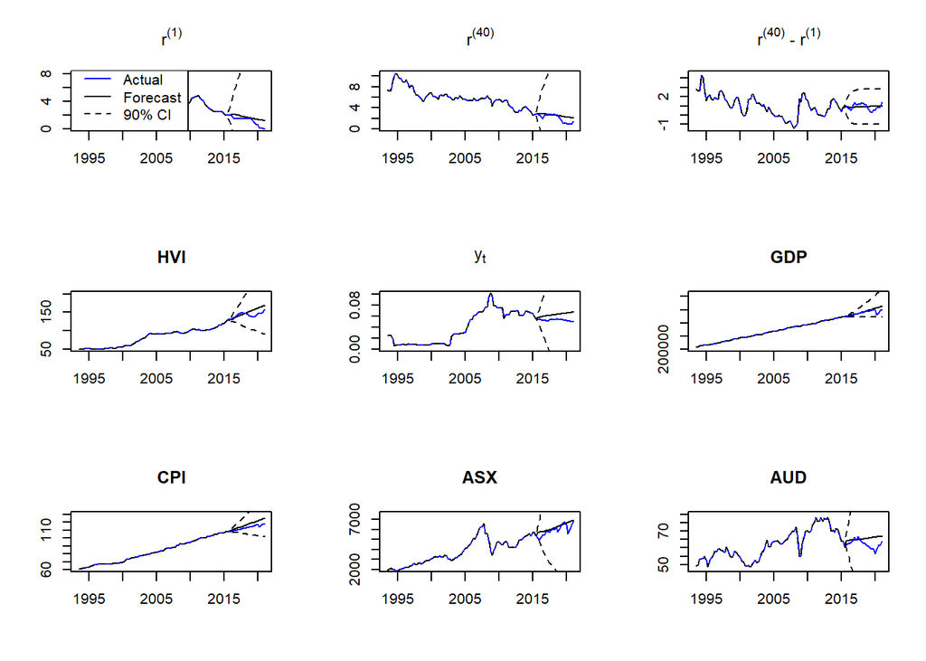

```r
##########
# forecast
test_forecast = predict(train_var, n.ahead = nrow(test), interval = "prediction", ci = 0.9)

##########################
# plots on original scales
par(mfrow = c(3,3))

############
# zcp3 month
zcp3m_forecast = zcp3m_inv(test_forecast$fcst$zcp3m_stationary[,1], all_data_original$zcp3m[max(train_index)])
plot_data_forecast = c(all_data_original$zcp3m[1+train_index]*100, zcp3m_forecast*100)
zcp3m_upper = zcp3m_inv(test_forecast$fcst$zcp3m_stationary[,3], all_data_original$zcp3m[max(train_index)])
plot_data_upper = c(all_data_original$zcp3m[1+train_index]*100, zcp3m_upper*100)
zcp3m_lower = zcp3m_inv(test_forecast$fcst$zcp3m_stationary[,2], all_data_original$zcp3m[max(train_index)])
plot_data_lower = c(all_data_original$zcp3m[1+train_index]*100, zcp3m_lower*100)

plot(all_data_original$Date[-1], plot_data_forecast, "l", ylim = c(-0.05, 8), main = TeX("r^{(1)}"), ylab = "", xlab = "")
lines(all_data_original$Date[-1], all_data_original$zcp3m[-1]*100, col = "blue")
lines(all_data_original$Date[-1], plot_data_upper, lty = 2)
lines(all_data_original$Date[-1], plot_data_lower, lty = 2)
legend("bottomleft", legend = c("Actual", "Forecast", "90% CI"), col = c("blue", "black", "black"), lty = c(1,1,2))


############
# zcp10 year
zcp10y_forecast = zcp10y_inv(test_forecast$fcst$zcp10y_spread[,1],  zcp3m_forecast)
plot_data_forecast = c(all_data_original$zcp10y[1+train_index]*100, zcp10y_forecast*100)
plot_data_upper = zcp10y_inv(test_forecast$fcst$zcp10y_spread[,3], zcp3m_upper)
plot_data_upper = c(all_data_original$zcp10y[1+train_index]*100, plot_data_upper*100)
plot_data_lower = zcp10y_inv(test_forecast$fcst$zcp10y_spread[,2], zcp3m_lower)
plot_data_lower = c(all_data_original$zcp10y[1+train_index]*100, plot_data_lower*100)

plot(all_data_original$Date[-1], plot_data_forecast, "l", ylim = c(0, 10.5), main = TeX("r^{(40)}"), ylab = "", xlab = "")
lines(all_data_original$Date[-1], all_data_original$zcp10y[-1]*100, col = "blue")
lines(all_data_original$Date[-1], plot_data_upper, lty = 2)
lines(all_data_original$Date[-1], plot_data_lower, lty = 2)


###################
# zcp10 year spread
plot_data_forecast = c(all_data[1+train_index,2]*100, test_forecast$fcst$zcp10y_spread[,1]*100)
plot_data_upper = c(all_data[1+train_index,2]*100, test_forecast$fcst$zcp10y_spread[,3]*100)
plot_data_lower = c(all_data[1+train_index,2]*100, test_forecast$fcst$zcp10y_spread[,2]*100)

plot(all_data_original$Date[-1], plot_data_forecast, "l", ylim = c(-1.5, 4.5), main = TeX("r^{(40)} - r^{(1)}"), ylab = "", xlab = "")
lines(all_data_original$Date[-1], all_data[-1,2]*100, col = "blue")
lines(all_data_original$Date[-1], plot_data_upper, lty = 2)
lines(all_data_original$Date[-1], plot_data_lower, lty = 2)


############
# home index
home_index_forecast = home_value_inv(test_forecast$fcst$home_value_houses_nsw[,1], all_data_original$home_index[max(train_index)])
plot_data_forecast = c(all_data_original$home_index[1+train_index], home_index_forecast)
plot_data_upper = home_value_inv(test_forecast$fcst$home_value_houses_nsw[,3], all_data_original$home_index[max(train_index)])
plot_data_upper = c(all_data_original$home_index[1+train_index], plot_data_upper)
plot_data_lower = home_value_inv(test_forecast$fcst$home_value_houses_nsw[,2], all_data_original$home_index[max(train_index)])
plot_data_lower = c(all_data_original$home_index[1+train_index], plot_data_lower)

plot(all_data_original$Date[-1], plot_data_forecast, "l", ylim = c(50, 200), main = "HVI", ylab = "", xlab = "")
lines(all_data_original$Date[-1], all_data_original$home_index[-1], col = "blue")
lines(all_data_original$Date[-1], plot_data_upper, lty = 2)
lines(all_data_original$Date[-1], plot_data_lower, lty = 2)


##############
# rental yield
rental_forecast = rental_inv(test_forecast$fcst$rental_houses_nsw_stationary[,1], all_data_original$rental_yield[max(train_index)])
plot_data_forecast = c(all_data_original$rental_yield[1+train_index], rental_forecast)
plot_data_upper = rental_inv(test_forecast$fcst$rental_houses_nsw_stationary[,3], all_data_original$rental_yield[max(train_index)])
plot_data_upper = c(all_data_original$rental_yield[1+train_index], plot_data_upper)
plot_data_lower = rental_inv(test_forecast$fcst$rental_houses_nsw_stationary[,2], all_data_original$rental_yield[max(train_index)])
plot_data_lower = c(all_data_original$rental_yield[1+train_index], plot_data_lower)

plot(all_data_original$Date[-1], plot_data_forecast, "l", ylim = c(0, 0.1), main = TeX("y_t"), ylab = "", xlab = "")
lines(all_data_original$Date[-1], all_data_original$rental_yield[-1], col = "blue")
lines(all_data_original$Date[-1], plot_data_upper, lty = 2)
lines(all_data_original$Date[-1], plot_data_lower, lty = 2)


################
# GDP
gdp_forecast = gdp_inv(test_forecast$fcst$gdp[,1], all_data_original$GDP[max(train_index)])
plot_data_forecast = c(all_data_original$GDP[1+train_index], gdp_forecast)
plot_data_upper = gdp_inv(test_forecast$fcst$gdp[,3], all_data_original$GDP[max(train_index)])
plot_data_upper = c(all_data_original$GDP[1+train_index], plot_data_upper)
plot_data_lower = rental_inv(test_forecast$fcst$gdp[,2], all_data_original$GDP[max(train_index)])
plot_data_lower = c(all_data_original$GDP[1+train_index], plot_data_lower)

plot(all_data_original$Date[-1], plot_data_forecast, "l", ylim = c(200000, 620000), main = "GDP", ylab = "", xlab = "")
lines(all_data_original$Date[-1], all_data_original$GDP[-1], col = "blue")
lines(all_data_original$Date[-1], plot_data_upper, lty = 2)
lines(all_data_original$Date[-1], plot_data_lower, lty = 2)


#####
# CPI
cpi_forecast = cpi_inv(test_forecast$fcst$cpi[,1], all_data_original$CPI[max(train_index)])
plot_data_forecast = c(all_data_original$CPI[1+train_index], cpi_forecast)
plot_data_upper = cpi_inv(test_forecast$fcst$cpi[,3], all_data_original$CPI[max(train_index)])
plot_data_upper = c(all_data_original$CPI[1+train_index], plot_data_upper)
plot_data_lower = cpi_inv(test_forecast$fcst$cpi[,2], all_data_original$CPI[max(train_index)])
plot_data_lower = c(all_data_original$CPI[1+train_index], plot_data_lower)

plot(all_data_original$Date[-1], plot_data_forecast, "l", ylim = c(60, 130), main = "CPI", ylab = "", xlab = "")
lines(all_data_original$Date[-1], all_data_original$CPI[-1], col = "blue")
lines(all_data_original$Date[-1], plot_data_upper, lty = 2)
lines(all_data_original$Date[-1], plot_data_lower, lty = 2)


############
# S&P/ASX200
asx200_forecast = asx_inv(test_forecast$fcst$asx200[,1], all_data_original$ASX200[max(train_index)])
plot_data_forecast = c(all_data_original$ASX200[1+train_index], asx200_forecast)
plot_data_upper = asx_inv(test_forecast$fcst$asx200[,3], all_data_original$ASX200[max(train_index)])
plot_data_upper = c(all_data_original$ASX200[1+train_index], plot_data_upper)
plot_data_lower = asx_inv(test_forecast$fcst$asx200[,2], all_data_original$ASX200[max(train_index)])
plot_data_lower = c(all_data_original$ASX200[1+train_index], plot_data_lower)

plot(all_data_original$Date[-1], plot_data_forecast, "l", ylim = c(2000, 7500), main = "ASX", ylab = "", xlab = "")
lines(all_data_original$Date[-1], all_data_original$ASX200[-1], col = "blue")
lines(all_data_original$Date[-1], plot_data_upper, lty = 2)
lines(all_data_original$Date[-1], plot_data_lower, lty = 2)


##############
# unemploymnet
# unemploy_forecast = unemploy_inv(test_forecast$fcst$unemploy_nsw_stationary[,1], all_data_original$unemploy[max(train_index)])
# plot_data_forecast = c(all_data_original$unemploy[1+train_index], unemploy_forecast)
# plot_data_upper = unemploy_inv(test_forecast$fcst$unemploy_nsw_stationary[,3], all_data_original$unemploy[max(train_index)])
# plot_data_upper = c(all_data_original$unemploy[1+train_index], plot_data_upper)
# plot_data_lower = unemploy_inv(test_forecast$fcst$unemploy_nsw_stationary[,2], all_data_original$unemploy[max(train_index)])
# plot_data_lower = c(all_data_original$unemploy[1+train_index], plot_data_lower)
#
# plot(all_data_original$Date[-1], plot_data_forecast, "l", ylim = c(4.2, 7), main = all_var_names[7], ylab = "", xlab = "")
# lines(all_data_original$Date[-1], all_data_original$unemploy[-1], col = "blue")
# lines(all_data_original$Date[-1], plot_data_upper, lty = 2)
# lines(all_data_original$Date[-1], plot_data_lower, lty = 2)


###########
# AUD index
forex_forecast = forex_inv(test_forecast$fcst$forex[,1], all_data_original$forex[max(train_index)])
plot_data_forecast = c(all_data_original$forex[1+train_index], forex_forecast)
plot_data_upper = forex_inv(test_forecast$fcst$forex[,3], all_data_original$forex[max(train_index)])
plot_data_upper = c(all_data_original$forex[1+train_index], plot_data_upper)
plot_data_lower = forex_inv(test_forecast$fcst$forex[,2], all_data_original$forex[max(train_index)])
plot_data_lower = c(all_data_original$forex[1+train_index], plot_data_lower)

plot(all_data_original$Date[-1], plot_data_forecast, "l", ylim = c(47, 80), main = "AUD", ylab = "", xlab = "")
lines(all_data_original$Date[-1], all_data_original$forex[-1], col = "blue")
lines(all_data_original$Date[-1], plot_data_upper, lty = 2)
lines(all_data_original$Date[-1], plot_data_lower, lty = 2)
```

#### 4.3.2.2 Metrics

```r
RMSE_test = as.data.frame(matrix(NA, nrow = 1, ncol = length(all_var_names)))
colnames(RMSE_test) = names(test_forecast$fcst)

RMSE_test$zcp3m_stationary = caret::RMSE(test_forecast$fcst$zcp3m_stationary[,1], zcp3m_stationary[-train_index])
RMSE_test$zcp10y_spread = caret::RMSE(test_forecast$fcst$zcp10y_spread[,1], zcp10y_spread[-train_index])
RMSE_test$home_value_houses_nsw = caret::RMSE(test_forecast$fcst$home_value_houses_nsw[,1], home_value_houses_nsw[-train_index])
RMSE_test$rental_houses_nsw_stationary = caret::RMSE(test_forecast$fcst$rental_houses_nsw_stationary[,1], rental_houses_nsw_stationary[-train_index])
RMSE_test$gdp = caret::RMSE(test_forecast$fcst$gdp[,1], gdp[-train_index])
RMSE_test$cpi = caret::RMSE(test_forecast$fcst$cpi[,1], cpi[-train_index])
RMSE_test$asx200 = caret::RMSE(test_forecast$fcst$asx200[,1], asx200[-train_index])
# RMSE_test$unemploy_nsw_stationary = caret::RMSE(test_forecast$fcst$unemploy_nsw_stationary[,1], unemploy_nsw_stationary[-train_index])
RMSE_test$forex = caret::RMSE(test_forecast$fcst$forex[,1], forex[-train_index])

MAE_test = as.data.frame(matrix(NA, nrow = 1, ncol = length(all_var_names)))
colnames(MAE_test) = names(test_forecast$fcst)
MAE_test$zcp3m_stationary = Metrics::mae(test_forecast$fcst$zcp3m_stationary[,1], zcp3m_stationary[-train_index])
MAE_test$zcp10y_spread = Metrics::mae(test_forecast$fcst$zcp10y_spread[,1], zcp10y_spread[-train_index])
MAE_test$home_value_houses_nsw = Metrics::mae(test_forecast$fcst$home_value_houses_nsw[,1], home_value_houses_nsw[-train_index])
MAE_test$rental_houses_nsw_stationary = Metrics::mae(test_forecast$fcst$rental_houses_nsw_stationary[,1], rental_houses_nsw_stationary[-train_index])
MAE_test$gdp = Metrics::mae(test_forecast$fcst$gdp[,1], gdp[-train_index])
MAE_test$cpi = Metrics::mae(test_forecast$fcst$cpi[,1], cpi[-train_index])
MAE_test$asx200 = Metrics::mae(test_forecast$fcst$asx200[,1], asx200[-train_index])
MAE_test$forex = Metrics::mae(test_forecast$fcst$forex[,1], forex[-train_index])

kbl(rbind(RMSE_test, MAE_test)) %>% kable_styling(latex_options = c("striped", "scale_down"))
```

| zcp3m_stationary | zcp10y_spread | home_value_houses_nsw | rental_houses_nsw_stationary | gdp | cpi | asx200 | forex |
| --- | --- | --- | --- | --- | --- | --- | --- |
| 0.001387 | 0.003397 | 0.020791 | 0.001225 | 0.019264 | 0.006796 | 0.050143 | 0.025055 |
| 0.000990 | 0.003022 | 0.018778 | 0.001118 | 0.008986 | 0.004008 | 0.038177 | 0.020939 |

```r
c(sqrt(rowMeans(RMSE_test^2)), rowMeans(MAE_test))
```

```
## [1] 0.0223792 0.0120026
```

#### 4.3.2.3 Diagnostics on full set

```r
###################################################################################################
resid_results = data.frame(chisq = rep(NA,4), pvalues = rep(NA,4), conclusion = rep(NA,4), row.names = c("Portmanteau test - white noise residuals", "Engle's ARCH test - white noise residuals", "Jarque-Bera Normality test - Skewness", "Jarque-Bera Normality test - Kurtosis"))

##################
# Portmanteau test
results = vars::serial.test(full_var, lags.pt = optimal_order, type = "PT.adjusted")
resid_results[1,1] = results$serial$statistic
resid_results[1,2] = results$serial$p.value
resid_results[1,3] = ifelse(resid_results[1,2] <= 0.05, "Not white noise", "White noise")

###############
# Lagrange test
results = vars::arch.test(full_var, lags.multi = optimal_order, multivariate.only = T)
resid_results[2,1] = results$arch.mul$statistic
resid_results[2,2] = results$arch.mul$p.value
resid_results[2,3] = ifelse(resid_results[2,2] <= 0.05, "Not white noise", "White noise")

#######################
# normality - skewness
results = vars::normality.test(full_var, multivariate.only = T)
resid_results[3,1] = results$jb.mul$Skewness$statistic
resid_results[3,2] = results$jb.mul$Skewness$p.value
resid_results[3,3] = ifelse(resid_results[3,2] <= 0.05, "Not normal", "Normal")

######################
# normality - kurtosis
resid_results[4,1] = results$jb.mul$Kurtosis$statistic
resid_results[4,2] = results$jb.mul$Kurtosis$p.value
resid_results[4,3] = ifelse(resid_results[4,2] <= 0.05, "Not normal", "Normal")

###############
# print results
kbl(resid_results) %>% kable_styling(latex_options = c("striped", "scale_down"))
```

|  | chisq | pvalues | conclusion |
| --- | --- | --- | --- |
| Portmanteau test - white noise residuals | 31.1431 | 0.000000 | Not white noise |
| Engle’s ARCH test - white noise residuals | 1512.8429 | 0.000025 | Not white noise |
| Jarque-Bera Normality test - Skewness | 478.9223 | 0.000000 | Not normal |
| Jarque-Bera Normality test - Kurtosis | 5996.4861 | 0.000000 | Not normal |

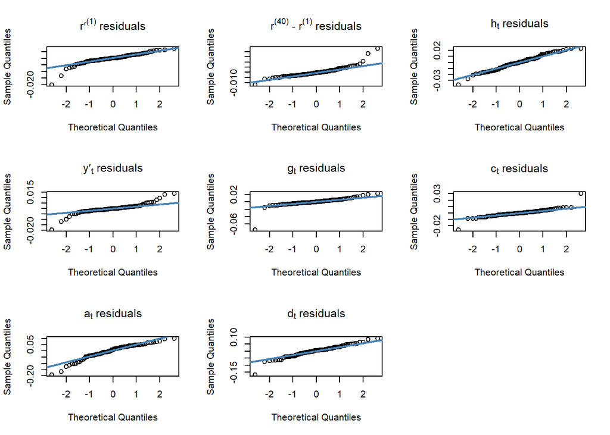

```r
###################################################################################################
full_res = residuals(full_var)

par(mfrow = c(3,3))
# zcp3m
qqnorm(full_res[,1], main = TeX("r'^{(1)}  residuals"))
qqline(full_res[,1], col = "steelblue", lwd = 2)
# zcp10y
qqnorm(full_res[,2], main = TeX("r^{(40)} - r^{(1)}  residuals"))
qqline(full_res[,2], col = "steelblue", lwd = 2)
# TeX("h_t")
qqnorm(full_res[,3], main = TeX("h_t  residuals"))
qqline(full_res[,3], col = "steelblue", lwd = 2)
# TeX("y'_t")
qqnorm(full_res[,4], main = TeX("y'_t  residuals"))
qqline(full_res[,4], col = "steelblue", lwd = 2)
# TeX("g_t")
qqnorm(full_res[,5], main = TeX("g_t  residuals"))
qqline(full_res[,5], col = "steelblue", lwd = 2)
# TeX("c_t")
qqnorm(full_res[,6], main = TeX("c_t  residuals"))
qqline(full_res[,6], col = "steelblue", lwd = 2)
# TeX("a_t")
qqnorm(full_res[,7], main = TeX("a_t  residuals"))
qqline(full_res[,7], col = "steelblue", lwd = 2)
# TeX("d_t")
qqnorm(full_res[,8], main = TeX("d_t  residuals"))
qqline(full_res[,8], col = "steelblue", lwd = 2)

###################################################################################################
par(mfrow = c(3,3))
```

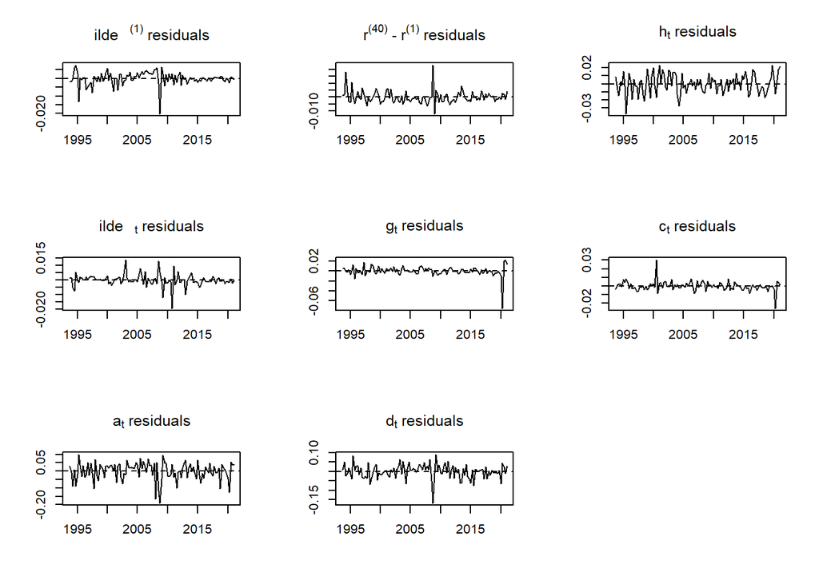

```r
# zcp3m
plot(all_data_original$Date[-c(1:2)], full_res[,1], "l", main = TeX("\tilde{r}^{(1)}  residuals"), xlab = "", ylab = "")
abline(h = 0, lty = 2)
# zcp10y
plot(all_data_original$Date[-c(1:2)], full_res[,2], "l", main = TeX("r^{(40)} - r^{(1)}  residuals"), xlab = "", ylab = "")
abline(h = 0, lty = 2)
# TeX("h_t")
plot(all_data_original$Date[-c(1:2)], full_res[,3], "l", main = TeX("h_t  residuals"), xlab = "", ylab = "")
abline(h = 0, lty = 2)
# TeX("\tilde{y}_t")
plot(all_data_original$Date[-c(1:2)], full_res[,4], "l", main = TeX("\tilde{y}_t  residuals"), xlab = "", ylab = "")
abline(h = 0, lty = 2)
# TeX("g_t")
plot(all_data_original$Date[-c(1:2)], full_res[,5], "l", main = TeX("g_t  residuals"), xlab = "", ylab = "")
abline(h = 0, lty = 2)
# TeX("c_t")
plot(all_data_original$Date[-c(1:2)], full_res[,6], "l", main = TeX("c_t  residuals"), xlab = "", ylab = "")
abline(h = 0, lty = 2)
# TeX("a_t")
plot(all_data_original$Date[-c(1:2)], full_res[,7], "l", main = TeX("a_t  residuals"), xlab = "", ylab = "")
abline(h = 0, lty = 2)
# TeX("d_t")
plot(all_data_original$Date[-c(1:2)], full_res[,8], "l", main = TeX("d_t  residuals"), xlab = "", ylab = "")
abline(h = 0, lty = 2)
```

## 4.4 Forecast

### 4.4.1 Simulations

```r
##########
# forecast
full_forecast = predict(full_var, n.ahead = 40, interval = "prediction", ci = 0.9)
forecast_date = c(all_data_original$Date[-1], as.yearqtr(seq(as.Date("2021-04-01"), by="quarter", length.out = 40)))

source("VAR_simulation.R")

num_paths = 10
sim_paths = get_var_simulations(num_years = 10, num_paths = 10)
```

### 4.4.2 Plots (original scale)

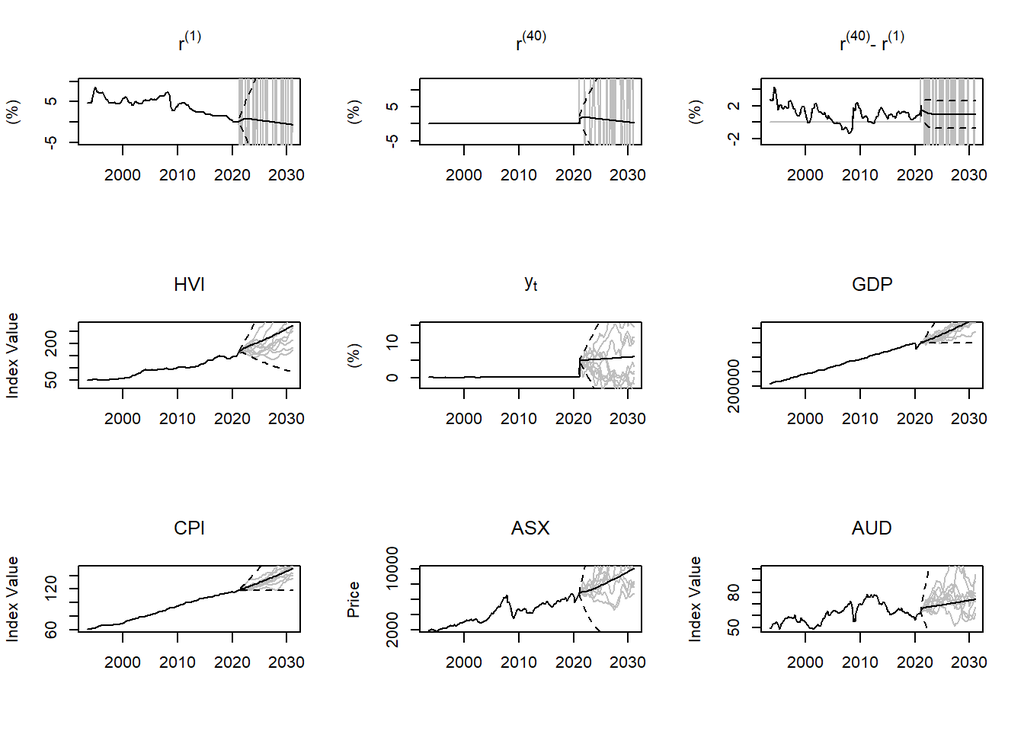

```r
##########################
# plots on original scales
par(mfrow = c(3,3))

############
# zcp3 month
# simulations
plot_data_forecast = c(all_data_original$zcp3m[-1]*100, sim_paths$zcp3m[,1]*100)
plot(forecast_date, plot_data_forecast, "l", ylim = c(-5, 10), main = TeX("r^{(1)}"), ylab = "(%)", xlab = "", col = "grey")
for (i in 2:(num_paths - 1)) {
    plot_data_forecast = c(all_data_original$zcp3m[-1]*100, sim_paths$zcp3m[,i]*100)
    lines(forecast_date, plot_data_forecast, col = "grey")
}
# central
zcp3m_forecast = zcp3m_inv(full_forecast$fcst$zcp3m_stationary[,1], all_data_original$zcp3m[nrow(all_data_original)])
plot_data_forecast = c(all_data_original$zcp3m[-1]*100, zcp3m_forecast*100)
lines(forecast_date, plot_data_forecast, col = "black")

# upper
zcp3m_upper = zcp3m_inv(full_forecast$fcst$zcp3m_stationary[,3], all_data_original$zcp3m[nrow(all_data_original)])
plot_data_upper = c(all_data_original$zcp3m[-1]*100, zcp3m_upper*100)
lines(forecast_date, plot_data_upper, lty = 2)

# lower
zcp3m_lower = zcp3m_inv(full_forecast$fcst$zcp3m_stationary[,2], all_data_original$zcp3m[nrow(all_data_original)])
plot_data_lower = c(all_data_original$zcp3m[-1]*100, zcp3m_lower*100)
lines(forecast_date, plot_data_lower, lty = 2)
# legend("bottomleft", legend = c("Forecast", "90% CI", "Simulations"), col = c("black", "black", "grey"), lty = c(1,2,1))


############
# zcp10 year
# simulations
plot_data_forecast = c(all_data_original$zcp10y[-1], sim_paths$zcp10y[,1]*100)
plot(forecast_date, plot_data_forecast, "l", ylim = c(-5.5, 12.5), main = TeX("r^{(40)}"), ylab = "(%)", xlab = "", col = "grey")
for (i in 2:(num_paths - 1)) {
    plot_data_forecast = c(all_data_original$zcp10y[-1], sim_paths$zcp10y[,i]*100)
    lines(forecast_date, plot_data_forecast, col = "grey")
}
# central
plot_data_forecast = zcp10y_inv(full_forecast$fcst$zcp10y_spread[,1], zcp3m_forecast)
plot_data_forecast = c(all_data_original$zcp10y[-1], plot_data_forecast*100)
lines(forecast_date, plot_data_forecast)
# upper
plot_data_upper = zcp10y_inv(full_forecast$fcst$zcp10y_spread[,3], zcp3m_upper)
plot_data_upper = c(all_data_original$zcp10y[-1], plot_data_upper*100)
lines(forecast_date, plot_data_upper, lty = 2)
# lower
plot_data_lower = zcp10y_inv(full_forecast$fcst$zcp10y_spread[,2], zcp3m_lower)
plot_data_lower = c(all_data_original$zcp10y[-1], plot_data_lower*100)
lines(forecast_date, plot_data_lower, lty = 2)


###################
# zcp10 year spread
# simulations
plot_data_forecast = c(all_data[-1,2], (sim_paths$zcp10y[,1] - sim_paths$zcp3m[,1])*100)
plot(forecast_date, plot_data_forecast, "l", ylim = c(-2.5, 5), main = TeX("r^{(40)}- r^{(1)}"), ylab = "(%)", xlab = "", col = "grey")
for (i in 2:(num_paths - 1)) {
    plot_data_forecast = c(all_data[-1,2], (sim_paths$zcp10y[,i] - sim_paths$zcp3m[,i])*100)
    lines(forecast_date, plot_data_forecast, col = "grey")
}
# central
plot_data_forecast = c(all_data[-1,2], full_forecast$fcst$zcp10y_spread[,1])
lines(forecast_date, plot_data_forecast*100)
# upper
plot_data_upper = c(all_data[-1,2], full_forecast$fcst$zcp10y_spread[,3])
lines(forecast_date, plot_data_upper*100, lty = 2)
# lower
plot_data_lower = c(all_data[-1,2], full_forecast$fcst$zcp10y_spread[,2])
lines(forecast_date, plot_data_lower*100, lty = 2)


############
# home index
# simulations
plot_data_forecast = c(all_data_original$home_index[-1], sim_paths$home_index[,1])
plot(forecast_date, plot_data_forecast, "l", ylim = c(25, 275), main = TeX("HVI"), ylab = "Index Value", xlab = "", col = "grey")
for (i in 2:(num_paths - 1)) {
    plot_data_forecast = c(all_data_original$home_index[-1], sim_paths$home_index[,i])
    lines(forecast_date, plot_data_forecast, col = "grey")
}
# central
plot_data_forecast = home_value_inv(full_forecast$fcst$home_value_houses_nsw[,1], all_data_original$home_index[nrow(all_data_original)])
plot_data_forecast = c(all_data_original$home_index[-1], plot_data_forecast)
lines(forecast_date, plot_data_forecast)
# upper
plot_data_upper = home_value_inv(full_forecast$fcst$home_value_houses_nsw[,3], all_data_original$home_index[nrow(all_data_original)])
plot_data_upper = c(all_data_original$home_index[-1], plot_data_upper)
lines(forecast_date, plot_data_upper, lty = 2)
# lower
plot_data_lower = home_value_inv(full_forecast$fcst$home_value_houses_nsw[,2], all_data_original$home_index[nrow(all_data_original)])
plot_data_lower = c(all_data_original$home_index[-1], plot_data_lower)
lines(forecast_date, plot_data_lower, lty = 2)


##############
# rental yield
# simulations
plot_data_forecast = c(all_data_original$rental_yield[-1], sim_paths$rental_yield[,1]*100)
plot(forecast_date, plot_data_forecast, "l", ylim = c(-2.5, 15), main = TeX("y_t"), ylab = "(%)", xlab = "", col = "grey")
for (i in 2:(num_paths - 1)) {
    plot_data_forecast = c(all_data_original$rental_yield[-1], sim_paths$rental_yield[,i]*100)
    lines(forecast_date, plot_data_forecast, col = "grey")
}
# central
plot_data_forecast = rental_inv(full_forecast$fcst$rental_houses_nsw_stationary[,1], all_data_original$rental_yield[nrow(all_data_original)])
plot_data_forecast = c(all_data_original$rental_yield[-1], plot_data_forecast*100)
lines(forecast_date, plot_data_forecast)
# upper
plot_data_upper = rental_inv(full_forecast$fcst$rental_houses_nsw_stationary[,3], all_data_original$rental_yield[nrow(all_data_original)])
plot_data_upper = c(all_data_original$rental_yield[-1], plot_data_upper*100)
lines(forecast_date, plot_data_upper, lty = 2)
# lower
plot_data_lower = rental_inv(full_forecast$fcst$rental_houses_nsw_stationary[,2], all_data_original$rental_yield[nrow(all_data_original)])
plot_data_lower = c(all_data_original$rental_yield[-1], plot_data_lower*100)
lines(forecast_date, plot_data_lower, lty = 2)


################
# GDP
# simulations
plot_data_forecast = c(all_data_original$GDP[-1], sim_paths$GDP[,1])
plot(forecast_date, plot_data_forecast, "l", ylim = c(200000, 625000), main = TeX("GDP"), ylab = "", xlab = "", col = "grey")
for (i in 2:(num_paths - 1)) {
    plot_data_forecast = c(all_data_original$GDP[-1], sim_paths$GDP[,i])
    lines(forecast_date, plot_data_forecast, col = "grey")
}
# central
plot_data_forecast = gdp_inv(full_forecast$fcst$gdp[,1], all_data_original$GDP[nrow(all_data_original)])
plot_data_forecast = c(all_data_original$GDP[-1], plot_data_forecast)
lines(forecast_date, plot_data_forecast)
# upper
plot_data_upper = gdp_inv(full_forecast$fcst$gdp[,3], all_data_original$GDP[nrow(all_data_original)])
plot_data_upper = c(all_data_original$GDP[-1], plot_data_upper)
lines(forecast_date, plot_data_upper, lty = 2)
# lower
plot_data_lower = rental_inv(full_forecast$fcst$gdp[,2], all_data_original$GDP[nrow(all_data_original)])
plot_data_lower = c(all_data_original$GDP[-1], plot_data_lower)
lines(forecast_date, plot_data_lower, lty = 2)


#####
# CPI
# simulations
plot_data_forecast = c(all_data_original$CPI[-1], sim_paths$CPI[,1])
plot(forecast_date, plot_data_forecast, "l", ylim = c(60, 150), main = TeX("CPI"), ylab = "Index Value", xlab = "", col = "grey")
for (i in 2:(num_paths - 1)) {
    plot_data_forecast = c(all_data_original$CPI[-1], sim_paths$CPI[,i])
    lines(forecast_date, plot_data_forecast, col = "grey")
}
# central
plot_data_forecast = cpi_inv(full_forecast$fcst$cpi[,1], all_data_original$CPI[nrow(all_data_original)])
plot_data_forecast = c(all_data_original$CPI[-1], plot_data_forecast)
lines(forecast_date, plot_data_forecast)
# upper
plot_data_upper = cpi_inv(full_forecast$fcst$cpi[,3], all_data_original$CPI[nrow(all_data_original)])
plot_data_upper = c(all_data_original$CPI[-1], plot_data_upper)
lines(forecast_date, plot_data_upper, lty = 2)
# lower
plot_data_lower = rental_inv(full_forecast$fcst$cpi[,2], all_data_original$CPI[nrow(all_data_original)])
plot_data_lower = c(all_data_original$CPI[-1], plot_data_lower)
lines(forecast_date, plot_data_lower, lty = 2)


############
# S&P/ASX200
# simulations
plot_data_forecast = c(all_data_original$ASX200[-1], sim_paths$ASX200[,1])
plot(forecast_date, plot_data_forecast, "l", ylim = c(2000, 10000), main = TeX("ASX"), ylab = "Price", xlab = "", col = "grey")
for (i in 2:(num_paths - 1)) {
    plot_data_forecast = c(all_data_original$ASX200[-1], sim_paths$ASX200[,i])
    lines(forecast_date, plot_data_forecast, col = "grey")
}
# central
plot_data_forecast = asx_inv(full_forecast$fcst$asx200[,1], all_data_original$ASX200[nrow(all_data_original)])
plot_data_forecast = c(all_data_original$ASX200[-1], plot_data_forecast)
lines(forecast_date, plot_data_forecast)
# upper
plot_data_upper = asx_inv(full_forecast$fcst$asx200[,3], all_data_original$ASX200[nrow(all_data_original)])
plot_data_upper = c(all_data_original$ASX200[-1], plot_data_upper)
lines(forecast_date, plot_data_upper, lty = 2)
# lower
plot_data_lower = asx_inv(full_forecast$fcst$asx200[,2], all_data_original$ASX200[nrow(all_data_original)])
plot_data_lower = c(all_data_original$ASX200[-1], plot_data_lower)
lines(forecast_date, plot_data_lower, lty = 2)


###########
# AUD index
# simulations
plot_data_forecast = c(all_data_original$forex[-1], sim_paths$AUD[,1])
plot(forecast_date, plot_data_forecast, "l", ylim = c(48, 100), main = TeX("AUD"), ylab = "Index Value", xlab = "", col = "grey")
for (i in 2:(num_paths - 1)) {
    plot_data_forecast = c(all_data_original$forex[-1], sim_paths$AUD[,i])
    lines(forecast_date, plot_data_forecast, col = "grey")
}
# central
plot_data_forecast = forex_inv(full_forecast$fcst$forex[,1], all_data_original$forex[nrow(all_data_original)])
plot_data_forecast = c(all_data_original$forex[-1], plot_data_forecast)
lines(forecast_date, plot_data_forecast)
# upper
plot_data_upper = forex_inv(full_forecast$fcst$forex[,3], all_data_original$forex[nrow(all_data_original)])
plot_data_upper = c(all_data_original$forex[-1], plot_data_upper)
lines(forecast_date, plot_data_upper, lty = 2)
# lower
plot_data_lower = forex_inv(full_forecast$fcst$forex[,2], all_data_original$forex[nrow(all_data_original)])
plot_data_lower = c(all_data_original$forex[-1], plot_data_lower)
lines(forecast_date, plot_data_lower, lty = 2)
```

### 4.4.3 Plot (stationary)

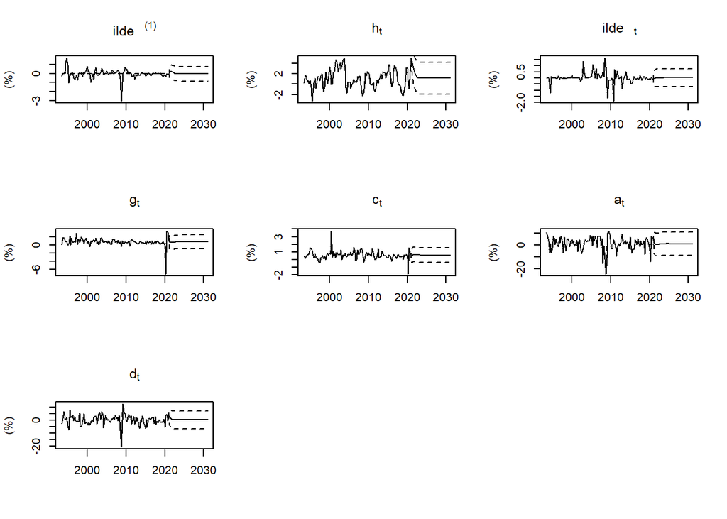

```r
##########################
# plots on stationary scales
par(mfrow = c(3,3))

sim_paths_stationary = sim_paths
sim_paths_stationary$zcp3m_yield = sim_paths$zcp3m_yield - dplyr::lag(sim_paths$zcp3m_yield, n = 1)
sim_paths_stationary$home_index = log(sim_paths$home_index) - log(dplyr::lag(sim_paths$home_index, n = 1))
sim_paths_stationary$rental_yield = sim_paths$rental_yield - dplyr::lag(sim_paths$rental_yield, n = 1)
sim_paths_stationary$GDP = log(sim_paths$GDP) - log(dplyr::lag(sim_paths$GDP, n = 1))
sim_paths_stationary$CPI = log(sim_paths$CPI) - log(dplyr::lag(sim_paths$CPI, n = 1))
sim_paths_stationary$ASX200 = log(sim_paths$ASX200) - log(dplyr::lag(sim_paths$ASX200, n = 1))

############
# zcp3 month
# central
plot_data_forecast = c(all_data_stationary[,1], full_forecast$fcst$zcp3m_stationary[,1])
plot(forecast_date, plot_data_forecast*100, "l", main = TeX("\tilde{r}^{(1)}"), ylab = "(%)", xlab = "")
# upper
plot_data_upper = c(all_data_stationary[,1], full_forecast$fcst$zcp3m_stationary[,3]*100)
lines(forecast_date, plot_data_upper, lty = 2)
# lower
plot_data_lower = c(all_data_stationary[,1], full_forecast$fcst$zcp3m_stationary[,2]*100)
lines(forecast_date, plot_data_lower, lty = 2)


############
# home value
# central
plot_data_forecast = c(all_data_stationary[,3], full_forecast$fcst$home_value_houses_nsw[,1])
plot(forecast_date, plot_data_forecast*100, "l", main = TeX("h_t"), ylab = "(%)", xlab = "")
# upper
plot_data_upper = c(all_data_stationary[,3], full_forecast$fcst$home_value_houses_nsw[,3])
lines(forecast_date, plot_data_upper*100, lty = 2)
# lower
plot_data_lower = c(all_data_stationary[,3], full_forecast$fcst$home_value_houses_nsw[,2])
lines(forecast_date, plot_data_lower*100, lty = 2)


##############
# rental yield
# central
plot_data_forecast = c(all_data_stationary[,4], full_forecast$fcst$rental_houses_nsw_stationary[,1])
plot(forecast_date, plot_data_forecast*100, "l", main = TeX("\tilde{y}_t"), ylab = "(%)", xlab = "")
# upper
plot_data_upper = c(all_data_stationary[,4], full_forecast$fcst$rental_houses_nsw_stationary[,3])
lines(forecast_date, plot_data_upper*100, lty = 2)
# lower
plot_data_lower = c(all_data_stationary[,4], full_forecast$fcst$rental_houses_nsw_stationary[,2])
lines(forecast_date, plot_data_lower*100, lty = 2)


################
# GDP
# central
plot_data_forecast = c(all_data_stationary[,5], full_forecast$fcst$gdp[,1])
plot(forecast_date, plot_data_forecast*100, "l", main = TeX("g_t"), ylab = "(%)", xlab = "")
# upper
plot_data_upper = c(all_data_stationary[,5], full_forecast$fcst$gdp[,3])
lines(forecast_date, plot_data_upper*100, lty = 2)
# lower
plot_data_lower = c(all_data_stationary[,5], full_forecast$fcst$gdp[,2])
lines(forecast_date, plot_data_lower*100, lty = 2)


#####
# CPI
# central
plot_data_forecast = c(all_data_stationary[,6], full_forecast$fcst$cpi[,1])
plot(forecast_date, plot_data_forecast*100, "l", main = TeX("c_t"), ylab = "(%)", xlab = "")
# upper
plot_data_upper = c(all_data_stationary[,6], full_forecast$fcst$cpi[,3])
lines(forecast_date, plot_data_upper*100, lty = 2)
# lower
plot_data_lower = c(all_data_stationary[,6], full_forecast$fcst$cpi[,2])
lines(forecast_date, plot_data_lower*100, lty = 2)


############
# S&P/ASX200
# central
plot_data_forecast = c(all_data_stationary[,7], full_forecast$fcst$asx200[,1])
plot(forecast_date, plot_data_forecast*100, "l", main = TeX("a_t"), ylab = "(%)", xlab = "")
# upper
plot_data_upper = c(all_data_stationary[,7], full_forecast$fcst$asx200[,3])
lines(forecast_date, plot_data_upper*100, lty = 2)
# lower
plot_data_lower = c(all_data_stationary[,7], full_forecast$fcst$asx200[,2])
lines(forecast_date, plot_data_lower*100, lty = 2)


###########
# AUD index
# central
plot_data_forecast = c(all_data_stationary[,8], full_forecast$fcst$forex[,1])
plot(forecast_date, plot_data_forecast*100, "l", main = TeX("d_t"), ylab = "(%)", xlab = "")
# upper
plot_data_upper = c(all_data_stationary[,8], full_forecast$fcst$forex[,3])
lines(forecast_date, plot_data_upper*100, lty = 2)
# lower
plot_data_lower = c(all_data_stationary[,8], full_forecast$fcst$forex[,2])
lines(forecast_date, plot_data_lower*100, lty = 2)
```